# Intro to R Curriculum- with Teacher Notes

Rosalee Elting

2024-05-27

What do # mean? Can remove freom chunks if miss steps, otherwise can write along in own chunk. have a “follow along” type and a “run only” type

# Doing calculations

```r
x <- 3 + 7
print(x)
```

```
## [1] 10
```

# Doing harder math: multi-step equations

Solve this equation: 3*(x-4)= 2*(-2x+1) 1. simplify by hand:  
3x-(3*4) = -4x +2 3x+4x = 14 7x = 14 2. here, a and b are coefficients (a = 7 and b =14) 3. enter these values as variables in R 4. use coefficeitns to solve for x

```r
#simplified equation: 7x=14
a <- 7
b <- 14

x = b/a
print(x)
```

```
## [1] 2
```

Now try another equation: -15x +21 +5x =-19 This one is a little easier, we only have to get all the integrers on one side and all the x’s on one side Simplified Equation: -10x = -40

```r
a <- -10
b <- -40
x <- b/a
print(x)
```

```
## [1] 4
```

# Making a Table

vector is a list. talk about how to make a list using c() and ” ”

```r
vegetables <- c("corn", "beans", "squash")
wk_after_frost <- c("2", "1", "2")
garden <- data.frame(vegetables, wk_after_frost)
View(garden)
```

# Creating data to graph

```r
x <- c(1, 2, 3, 4, 5, 6, 7, 8, 9)
y <- c(0.75, 1.0, 1.5, 2.0, 2.25, 3.0, 4, 3.75, 5.0)
```

# Types of graph R can make

x and y: the coordinates of points to plot type : the type of graph to create; Possible values are : type=“p”: for points (by default) type=“l”: for lines type=“b”: for both; points are connected by a line type=“o”: for both ‘overplotted’; type=“h”: for ‘histogram’ like vertical lines type=“s”: for stair steps type=“n”: for no plotting

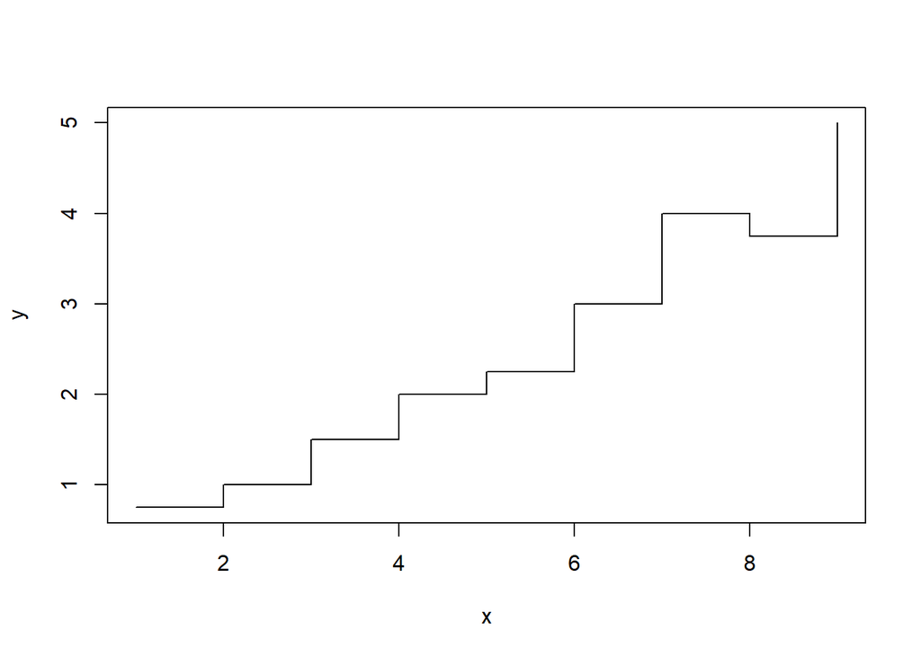

```r
plot(x, y, type= "s")
```

# base R comes with some data!

Here is a link to find a data set we want to work with: https://stat.ethz.ch/R-manual/R-devel/library/datasets/html/00Index.html

# Example with a data set.

warpbreaks package could be interesting

# a pretty plot with base R

graph set up

```r
x <- 1:100
y <- (rnorm(100, sd = 15) + x + 100) / 10
group <- c(rep("A", 50), rep("B", 50))

k_purple <- "#875692"
k_orange <- "#F38400"
colors <- c(A = k_purple, B = k_orange)
```

A base R plot

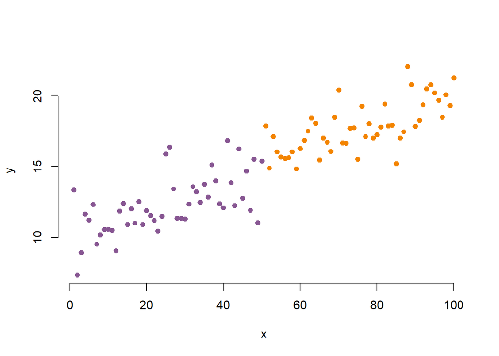

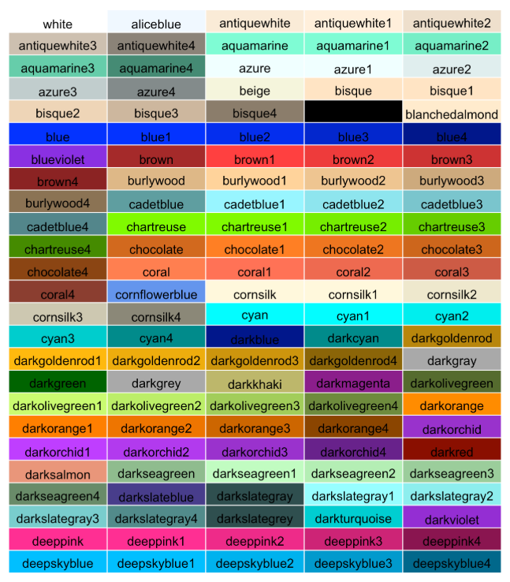

colors to choose from

```r
plot (x, y,
      bty = "n", # remove box
      pch = 20,
      cex = 1.4,
      col = colors[group]
      )
```

Colors to choose from